# Settling on Success: How to Answer “What Are Your Salary Expectations?”

## Spring 2024 Data Science Project

Brian Xie, Kyle Kuo, Shu-Ye Lin

# Contributions

## Contribution Percentage by Member

**Member 1**: Brian Xie, Contribution: 100%

**Member 2**: Kyle Kuo, Contribution: 100%

**Member 3**: Shu-Ye Lin, Contribution: 100%

We, Brian Xie, Kyle Kuo, and Shu-Ye Lin, agree together that the above information is true, and we are confident about our contributions to this submitted project/final tutorial.

## Member Contribution Description

**Brian Xie, Shu-Ye Lin, Kyle Kuo**

While all of us worked together on each section, each of us took initiative in leading different sections.

For instance, during one of our group meetings to complete the data analysis section, Brian researched suitable machine learning models to settle on the RandomForestRegressor classifier, while Kyle and Shu-Ye worked on implementing this model with our dataset. When we inevitably ran into errors, Brian, Kyle, and Shu-Ye worked together to bug the error and took to the internet to find ways to resolve it. This was how Brian, Kyle, and Shu-Ye worked on each section of the project. In fact, for a majority of the process, all 3 members worked together on the same device, contributing feedback, ideas, and knowledge while one designated member, who rotated every few minutes, did the physical typing.

In effect, all members both physically and mentally contributed to each section equally.

# Introduction

Interviews are one of the most crucial, yet stressful parts of the application process, and this is only exacerbated by job searching’s competitive landscape. [Hiring freezes](https://www.msn.com/en-us/money/markets/the-job-market-is-getting-stuck-hiring-firing-and-quitting-all-fell-in-march/ar-AA1nZOmy) and [layoffs](https://www.businessinsider.com/google-layoffs-flutter-dart-python-job-cuts-tech-2024-4) make securing that first job especially important. While seemingly innocent, the question, “**What are your salary expectations?**” carries great weight in determining the personality, thinking, and future of a potential applicant [according to CNBC](https://www.cnbc.com/2022/01/26/how-to-answer-what-are-your-salary-expectations-and-talk-pay-in-job-interviews.html). As a result, it is imperative to provide a satisfactory answer to demonstrate confidence, preparation, and appeal, and increase the chance of landing a job offer.

While a quick Google Search can provide basic information about salary ranges or expectations, the ranges are often broad and expectations can vary from company to company. However, in recent times, data on companies and occupations is easily accessible, and we hypothesize that a more accurate salary expectation can be derived through a combination of company data analysis and machine learning.

More specifically, we seek to create a model to predict a suitable salary expectation given various aspects of a job: application type, experience requirements, job posting views, etc. This allows the applicant to confidently prepare for and answer the inevitable question: **what are your salary expectations**?

To answer this, we ask the following 2 questions:

1. Can we predict a position's yearly salary given various information about the position?
2. Which features of a position's description contribute the most when predicting the yearly salary?

# Data Curation

## Data Source

To obtain the most diverse, accessible array of job information, we turn to **LinkedIn**, an online social network where employers often list their job postings as well as various pieces of information about the company and job posting. We use a dataset from **[Kaggle](https://www.kaggle.com/)**, an online data science community with countless open datasets; [this specific LinkedIn dataset](https://www.kaggle.com/datasets/arshkon/linkedin-job-postings?resource=download) was collected by *Arsh Kon* and *Zoey Yu Zou*. It was accumulated using LinkedIn’s backend search API and scrapped over the course of 2 days, months apart.

The dataset is initially represented in a csv; it contains information about thousands of job postings, with each posting holding up to 27 attributes. As such, before our preprocessing and exploratory data analysis, we deemed that the best way to represent the data was by organizing a pandas DataFrame: each row is a job posting, and each column is one of its attributes.

## Imports and Preprocessing

Let's import our data and prepare it for analysis!

We begin by importing the libraries we need for this project. An interested reader can refer to the following resources for documentation regarding these libraries:

- [Pandas Documentation](https://pandas.pydata.org/docs/)
- [Numpy Documentation](https://numpy.org/doc/)
- [Scipy Documentation](https://docs.scipy.org/doc//scipy/index.html)
- [Seaborn Documentation](https://seaborn.pydata.org/)
- [Sklearn Documentation](https://scikit-learn.org/stable/index.html)

```python
# Data storage and formatting
import pandas as pd

import numpy as np
import datetime as datetime

# Data analysis and visualizations
import scipy as sci
import seaborn as sns
import matplotlib.pyplot as plt

# Machine Learning Libraries
from sklearn.model_selection import train_test_split
from sklearn.ensemble import RandomForestRegressor
from sklearn.metrics import mean_squared_error
from sklearn.metrics import r2_score
```

Now, using `pandas`, import the `job_postings` dataset. This dataset contains the majority of our job information, which we will use to answer our question.

```python
with open('job_postings.csv', 'r', encoding='utf-8', errors='ignore') as file:
    job_postings = pd.read_csv(file)
```

Now, let's take a look at our data.

```python
job_postings.head(5)
```

|  | job_id | company_id | title | description | max_salary | med_salary | min_salary | pay_period | formatted_work_type | location | ... | closed_time | formatted_experience_level | skills_desc | listed_time | posting_domain | sponsored | work_type | currency | compensation_type | scraped |
| --- | --- | --- | --- | --- | --- | --- | --- | --- | --- | --- | --- | --- | --- | --- | --- | --- | --- | --- | --- | --- | --- |
| 0 | 3757940104 | 553718.0 | Hearing Care Provider | Overview\n\nHearingLife is a national hearing ... | NaN | 5250.00 | NaN | MONTHLY | Full-time | Little River, SC | ... | NaN | Entry level | NaN | 1.699090e+12 | careers-demant.icims.com | 0 | FULL_TIME | USD | BASE_SALARY | 1699138101 |
| 1 | 3757940025 | 2192142.0 | Shipping & Receiving Associate 2nd shift (Beav... | Metalcraft of Mayville\nMetalcraft of Mayville... | NaN | NaN | NaN | NaN | Full-time | Beaver Dam, WI | ... | NaN | NaN | NaN | 1.699080e+12 | www.click2apply.net | 0 | FULL_TIME | NaN | NaN | 1699085420 |
| 2 | 3757938019 | 474443.0 | Manager, Engineering | \nThe TSUBAKI name is synonymous with excellen... | NaN | NaN | NaN | NaN | Full-time | Bessemer, AL | ... | NaN | NaN | Bachelor's Degree in Mechanical Engineering pr... | 1.699080e+12 | www.click2apply.net | 0 | FULL_TIME | NaN | NaN | 1699085644 |
| 3 | 3757938018 | 18213359.0 | Cook | descriptionTitle\n\n Looking for a great oppor... | NaN | 22.27 | NaN | HOURLY | Full-time | Aliso Viejo, CA | ... | NaN | Entry level | NaN | 1.699080e+12 | jobs.apploi.com | 0 | FULL_TIME | USD | BASE_SALARY | 1699087461 |
| 4 | 3757937095 | 437225.0 | Principal Cloud Security Architect (Remote) | Job Summary\nAt iHerb, we are on a mission to ... | 275834.0 | NaN | 205956.0 | YEARLY | Full-time | United States | ... | NaN | Mid-Senior level | NaN | 1.699090e+12 | careers.iherb.com | 0 | FULL_TIME | USD | BASE_SALARY | 1699085346 |

5 rows × 28 columns

As we want to be able to determine salary expectations, we must first standardize our salary data; it is initially given in multiple different data formats: minimum salary, average salary, and maximum salary. These formats are further subdivided into salaries given by different pay periods - from hourly, to monthly, to yearly.

For our purposes, we will work with average yearly salary for jobs, if given. To do this, we will average the job's minimum and maximum salary (if they exist), or take the given average salary.

```python
# Drop the single "ONCE" pay period, as it is not a salary and is thus
# not relevant to our analysis
job_postings = job_postings[job_postings["pay_period"] != "ONCE"]

# Conversions to yearly salary
SALARY_MULTPLIER = {
  "WEEKLY": 52,       # 52 Weeks / Year
  "MONTHLY": 12,      # 12 Months / Year
  "HOURLY": 10 * 52,  # 10 Working Hours / Week * 52 Weeks / Year
  "YEARLY": 1         # Already on a Per-Year Basis
}

# Function that takes a row in the dataframe and returns the average
# yearly salary (or NaN, if this salary cannot be found)
def average_salaries(row):
  pay_period = row["pay_period"]
  yearly_salary = pd.NA

  if not pd.isna(pay_period):
    if not pd.isna(row["med_salary"]):
      yearly_salary = SALARY_MULTPLIER[pay_period] * row["med_salary"]
    elif not pd.isna(row["min_salary"]) and not pd.isna(row["max_salary"]):
      average = (row["min_salary"] + row["max_salary"]) / 2
      yearly_salary = SALARY_MULTPLIER[pay_period] * average

  return yearly_salary

# Average salaries
job_postings["salary"] = job_postings.apply(average_salaries, axis = 1)

job_postings.head(5)
```

|  | job_id | company_id | title | description | max_salary | med_salary | min_salary | pay_period | formatted_work_type | location | ... | formatted_experience_level | skills_desc | listed_time | posting_domain | sponsored | work_type | currency | compensation_type | scraped | salary |
| --- | --- | --- | --- | --- | --- | --- | --- | --- | --- | --- | --- | --- | --- | --- | --- | --- | --- | --- | --- | --- | --- |
| 0 | 3757940104 | 553718.0 | Hearing Care Provider | Overview\n\nHearingLife is a national hearing ... | NaN | 5250.00 | NaN | MONTHLY | Full-time | Little River, SC | ... | Entry level | NaN | 1.699090e+12 | careers-demant.icims.com | 0 | FULL_TIME | USD | BASE_SALARY | 1699138101 | 63000.0 |
| 1 | 3757940025 | 2192142.0 | Shipping & Receiving Associate 2nd shift (Beav... | Metalcraft of Mayville\nMetalcraft of Mayville... | NaN | NaN | NaN | NaN | Full-time | Beaver Dam, WI | ... | NaN | NaN | 1.699080e+12 | www.click2apply.net | 0 | FULL_TIME | NaN | NaN | 1699085420 | <NA> |
| 2 | 3757938019 | 474443.0 | Manager, Engineering | \nThe TSUBAKI name is synonymous with excellen... | NaN | NaN | NaN | NaN | Full-time | Bessemer, AL | ... | NaN | Bachelor's Degree in Mechanical Engineering pr... | 1.699080e+12 | www.click2apply.net | 0 | FULL_TIME | NaN | NaN | 1699085644 | <NA> |
| 3 | 3757938018 | 18213359.0 | Cook | descriptionTitle\n\n Looking for a great oppor... | NaN | 22.27 | NaN | HOURLY | Full-time | Aliso Viejo, CA | ... | Entry level | NaN | 1.699080e+12 | jobs.apploi.com | 0 | FULL_TIME | USD | BASE_SALARY | 1699087461 | 11580.4 |
| 4 | 3757937095 | 437225.0 | Principal Cloud Security Architect (Remote) | Job Summary\nAt iHerb, we are on a mission to ... | 275834.0 | NaN | 205956.0 | YEARLY | Full-time | United States | ... | Mid-Senior level | NaN | 1.699090e+12 | careers.iherb.com | 0 | FULL_TIME | USD | BASE_SALARY | 1699085346 | 240895.0 |

5 rows × 29 columns

Now that we've standardized our salary to be a yearly salary, we'll drop the other salary columns, which are now unnecessary. We will also drop all salaries which are NaN, as without a salary label, we won't be able to use the data to answer our question.

```python
# Now that we've processed salary, drop the other salary columns
job_postings.drop("min_salary", axis = 1, inplace = True)
job_postings.drop("med_salary", axis = 1, inplace = True)
job_postings.drop("max_salary", axis = 1, inplace = True)

# Drop all NaN salaries
job_postings = job_postings[job_postings["salary"].notna()]

print("Number of Entries: ", len(job_postings))
job_postings.head(5)
```

```
Number of Entries:  13351
```

|  | job_id | company_id | title | description | pay_period | formatted_work_type | location | applies | original_listed_time | remote_allowed | ... | formatted_experience_level | skills_desc | listed_time | posting_domain | sponsored | work_type | currency | compensation_type | scraped | salary |
| --- | --- | --- | --- | --- | --- | --- | --- | --- | --- | --- | --- | --- | --- | --- | --- | --- | --- | --- | --- | --- | --- |
| 0 | 3757940104 | 553718.0 | Hearing Care Provider | Overview\n\nHearingLife is a national hearing ... | MONTHLY | Full-time | Little River, SC | NaN | 1.699090e+12 | NaN | ... | Entry level | NaN | 1.699090e+12 | careers-demant.icims.com | 0 | FULL_TIME | USD | BASE_SALARY | 1699138101 | 63000.0 |
| 3 | 3757938018 | 18213359.0 | Cook | descriptionTitle\n\n Looking for a great oppor... | HOURLY | Full-time | Aliso Viejo, CA | NaN | 1.699080e+12 | NaN | ... | Entry level | NaN | 1.699080e+12 | jobs.apploi.com | 0 | FULL_TIME | USD | BASE_SALARY | 1699087461 | 11580.4 |
| 4 | 3757937095 | 437225.0 | Principal Cloud Security Architect (Remote) | Job Summary\nAt iHerb, we are on a mission to ... | YEARLY | Full-time | United States | NaN | 1.698970e+12 | 1.0 | ... | Mid-Senior level | NaN | 1.699090e+12 | careers.iherb.com | 0 | FULL_TIME | USD | BASE_SALARY | 1699085346 | 240895.0 |
| 8 | 3757936097 | 18213359.0 | Dishwasher | descriptionTitle\n\n $2,000 Sign-on Bonus Guar... | HOURLY | Full-time | Aliso Viejo, CA | NaN | 1.699080e+12 | NaN | ... | Entry level | NaN | 1.699080e+12 | jobs.apploi.com | 0 | FULL_TIME | USD | BASE_SALARY | 1699089324 | 10036.0 |
| 11 | 3757935381 | 19181907.0 | Insights Analyst - Auto Industry | Who We Are\n\nEscalent is an award-winning dat... | YEARLY | Full-time | United States | NaN | 1.698960e+12 | 1.0 | ... | Entry level | NaN | 1.699090e+12 | escalent.hrmdirect.com | 0 | FULL_TIME | USD | BASE_SALARY | 1699134111 | 61000.0 |

5 rows × 26 columns

This leaves us with 13,351 data entries to work with!

Let's now cleanup the rest of our features, so they're easier to use later. We'll transform features into formats that are more convenient to use. For instance, instead of analyzing the description with a natural language processing, we instead analyze the length of the description. We also use hot-deck imputation to reasonably fill in missing data and transformations to change our data into more convenient formats.

```python
# Drop title column, as we will not use it - there's no standard way to
# name jobs, so title will not be a very good predictor.
job_postings = job_postings.drop("title", axis = 1)

# Find character length of job description
job_postings["description"] = job_postings["description"].apply(str).apply(len)
job_postings.rename(columns = {"description" : "desc_length"}, inplace = True)

# If remote allowed is not given (NaN), the job is likely not-remote.
# Thus, we will impute NaN to be 0
job_postings["remote_allowed"] = job_postings["remote_allowed"].fillna(0)

# If applies is not given, LinkedIn doesn't report any applied.
# Thus, we will impute NaN to be 0
job_postings["applies"] = job_postings["applies"].fillna(0)

# If views is not given, LinkedIn doesn't report any views.
# Thus, we will impute NaN to be 0
job_postings["views"] = job_postings["views"].fillna(0)

# Impute NaN for exp_level to be similar rows (hot-deck imputation)
job_postings["formatted_experience_level"] = job_postings.fillna(method="ffill")["formatted_experience_level"]
job_postings.rename(columns = {"formatted_experience_level" : "exp_level"}, inplace = True)

# Determine the timeframe of job posting in hours
job_postings["original_listed_time"] = pd.to_datetime(job_postings["original_listed_time"].map(float), unit='ms', origin = 'unix')
job_postings["expiry"] = pd.to_datetime(job_postings["expiry"].map(float), unit='ms', origin = 'unix')
job_postings["time"] = (job_postings["expiry"] - job_postings["original_listed_time"]).dt.total_seconds() // 3600
job_postings.drop("original_listed_time", axis = 1, inplace = True)
job_postings.drop("expiry", axis = 1, inplace = True)

# Remove existing (unformatted) work type, and rename formatted_work_type to work_type
job_postings.drop("work_type", axis = 1, inplace = True)
job_postings.rename(columns = {"formatted_work_type" : "work_type"}, inplace = True)
```

We will also drop features that we won't use. Some reasons for this are described below:

- **Listed Time & Closing Time**: Combined into the "time" column, storing the number of hours between the application opening time and deadline.
- **Currency**: All currency is given in USD, so currency information won't tell us anything useful.
- **URLs & Posting Domain**: URLs serve as portals to the application, so its information won't tell us anything useful about the salary.
- **Scraped**: Only used internally to measure when the job was found. As applicants won't be able to see this information, it won't tell us anything useful.
- **Applies**: Applicants won't know how many people applied until the deadline closes, so this information won't be relevant to them in determining salary.

```python
# Drop columns we will not use, as we will not use it
unused_columns = ["location", "job_posting_url", "application_url", \
                  "closed_time", "skills_desc", "listed_time", \
                  "posting_domain", "sponsored", "currency", \
                  "compensation_type", "scraped"]
for col in unused_columns:
  job_postings.drop(col, axis = 1, inplace = True)

# Print our current dataset
job_postings.head(5)
```

|  | job_id | company_id | desc_length | pay_period | work_type | applies | remote_allowed | views | application_type | exp_level | salary | time |
| --- | --- | --- | --- | --- | --- | --- | --- | --- | --- | --- | --- | --- |
| 0 | 3757940104 | 553718.0 | 5246 | MONTHLY | Full-time | 0.0 | 0.0 | 9.0 | OffsiteApply | Entry level | 63000.0 | 719.0 |
| 3 | 3757938018 | 18213359.0 | 2950 | HOURLY | Full-time | 0.0 | 0.0 | 1.0 | OffsiteApply | Entry level | 11580.4 | 722.0 |
| 4 | 3757937095 | 437225.0 | 7695 | YEARLY | Full-time | 0.0 | 1.0 | 0.0 | OffsiteApply | Mid-Senior level | 240895.0 | 752.0 |
| 8 | 3757936097 | 18213359.0 | 2546 | HOURLY | Full-time | 0.0 | 0.0 | 0.0 | OffsiteApply | Entry level | 10036.0 | 722.0 |
| 11 | 3757935381 | 19181907.0 | 5725 | YEARLY | Full-time | 0.0 | 1.0 | 130.0 | OffsiteApply | Entry level | 61000.0 | 755.0 |

Let's also add some additional data provided in other datasets! This way, we have more features that may be potentially good predictors.

```python
# Import employee and follower counts
employee_follower_df = pd.read_csv("employee_counts.csv")

# Make companies unique, choosing the most recent recording time for the company
employee_follower_df.sort_values(by = "time_recorded", inplace = True)
employee_follower_df.drop_duplicates("company_id", keep = "last", inplace = True)

# Merge into job postings
job_postings = pd.merge(job_postings, employee_follower_df, on = "company_id", how = "left")
job_postings.drop("time_recorded", axis = 1, inplace = True)

# Impute missing employees and followers with mode imputation,
job_postings["employee_count"] = job_postings["employee_count"].fillna(job_postings["employee_count"].median())
job_postings["follower_count"] = job_postings["follower_count"].fillna(job_postings["follower_count"].median())

# Import job benefits
benefits_df = pd.read_csv("benefits.csv")
benefits_df = benefits_df.drop(columns="inferred")

# Merge benefit types into dataframe and apply one-hot encoding
n = len(job_postings.columns)
temp = pd.get_dummies(benefits_df['type'],dtype=int)
updated_df = pd.concat([benefits_df, temp], axis=1)
gdf = updated_df.groupby('job_id').sum()
gdf = gdf.drop(columns="type")
filter = gdf[gdf.index.isin(job_postings["job_id"])]
job_postings = pd.merge(job_postings, filter, on='job_id', how='left')
nan_data = job_postings.iloc[:, n:].isna()

# Fill NaN values with 0 only where the mask is True, as this means
# benefits are not given
job_postings.iloc[:, 2:] = job_postings.iloc[:, 2:].fillna({col: 0 for col in nan_data.columns})
```

Here is our data, ready for analysis!

```python
job_postings.head(10)
```

|  | job_id | company_id | desc_length | pay_period | work_type | applies | remote_allowed | views | application_type | exp_level | ... | Commuter benefits | Dental insurance | Disability insurance | Medical insurance | Paid maternity leave | Paid paternity leave | Pension plan | Student loan assistance | Tuition assistance | Vision insurance |
| --- | --- | --- | --- | --- | --- | --- | --- | --- | --- | --- | --- | --- | --- | --- | --- | --- | --- | --- | --- | --- | --- |
| 0 | 3757940104 | 553718.0 | 5246 | MONTHLY | Full-time | 0.0 | 0.0 | 9.0 | OffsiteApply | Entry level | ... | 0.0 | 0.0 | 1.0 | 1.0 | 0.0 | 0.0 | 0.0 | 0.0 | 0.0 | 0.0 |
| 1 | 3757938018 | 18213359.0 | 2950 | HOURLY | Full-time | 0.0 | 0.0 | 1.0 | OffsiteApply | Entry level | ... | 0.0 | 0.0 | 0.0 | 0.0 | 0.0 | 0.0 | 0.0 | 0.0 | 0.0 | 0.0 |
| 2 | 3757937095 | 437225.0 | 7695 | YEARLY | Full-time | 0.0 | 1.0 | 0.0 | OffsiteApply | Mid-Senior level | ... | 0.0 | 0.0 | 0.0 | 0.0 | 0.0 | 0.0 | 0.0 | 0.0 | 0.0 | 0.0 |
| 3 | 3757936097 | 18213359.0 | 2546 | HOURLY | Full-time | 0.0 | 0.0 | 0.0 | OffsiteApply | Entry level | ... | 0.0 | 0.0 | 0.0 | 0.0 | 0.0 | 0.0 | 0.0 | 0.0 | 0.0 | 0.0 |
| 4 | 3757935381 | 19181907.0 | 5725 | YEARLY | Full-time | 0.0 | 1.0 | 130.0 | OffsiteApply | Entry level | ... | 0.0 | 0.0 | 0.0 | 0.0 | 0.0 | 0.0 | 0.0 | 0.0 | 0.0 | 1.0 |
| 5 | 3757935001 | 73013724.0 | 3391 | YEARLY | Full-time | 0.0 | 1.0 | 0.0 | ComplexOnsiteApply | Mid-Senior level | ... | 0.0 | 0.0 | 0.0 | 0.0 | 0.0 | 0.0 | 0.0 | 0.0 | 0.0 | 0.0 |
| 6 | 3757934423 | 18213359.0 | 2274 | HOURLY | Full-time | 0.0 | 0.0 | 0.0 | OffsiteApply | Entry level | ... | 0.0 | 0.0 | 0.0 | 0.0 | 0.0 | 0.0 | 0.0 | 0.0 | 0.0 | 0.0 |
| 7 | 3757934347 | 10515052.0 | 3424 | HOURLY | Full-time | 0.0 | 0.0 | 0.0 | OffsiteApply | Entry level | ... | 0.0 | 0.0 | 1.0 | 0.0 | 0.0 | 0.0 | 0.0 | 0.0 | 0.0 | 1.0 |
| 8 | 3757934319 | 18391435.0 | 4761 | YEARLY | Full-time | 1.0 | 0.0 | 5.0 | OffsiteApply | Mid-Senior level | ... | 0.0 | 0.0 | 0.0 | 0.0 | 0.0 | 0.0 | 0.0 | 0.0 | 0.0 | 0.0 |
| 9 | 3757934318 | 6577380.0 | 2609 | HOURLY | Full-time | 0.0 | 0.0 | 0.0 | OffsiteApply | Mid-Senior level | ... | 0.0 | 1.0 | 1.0 | 1.0 | 0.0 | 0.0 | 0.0 | 0.0 | 0.0 | 1.0 |

10 rows × 26 columns

# Exploratory Data Analysis

To determine the data analysis technique we want to use, we first want to explore our data.

Let's start by plotting a boxplot of our salaries, to see our initial salary distributions.

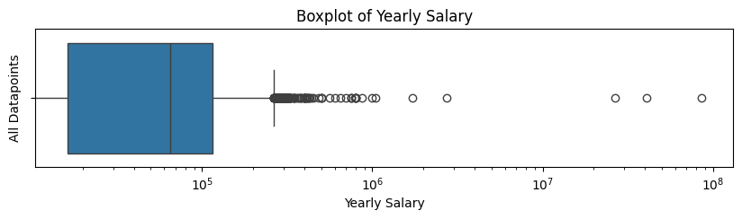

```python
# Plot boxplot for salary
plt.figure(figsize=(10, 2))
sns.boxplot(data = job_postings["salary"], orient = 'h')

# Set logarithmic scale to see plot better
plt.xscale('log')

# Label plots
plt.xlabel("Yearly Salary")
plt.ylabel("All Datapoints")
plt.title("Boxplot of Yearly Salary")

# Display
plt.show()
```

From this boxplot, we can see quite a few outliers! It makes sense for some jobs to be significantly higher paying than others, but even then, some of these jobs are reporting salaries far outside of a typical salary range. Because of this, we will drop these obvious outliers, as the average job most people apply to will not have an incredibly high salary so including them in our data set would only introduce extraneous noise.

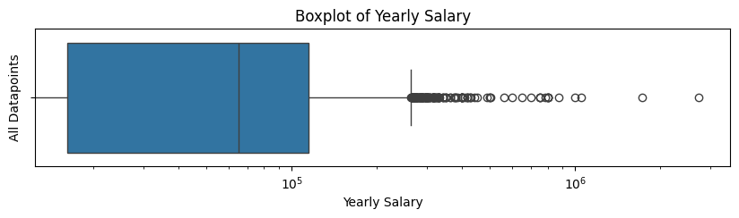

```python
# Drop outliers 5 z-scores away
mean = np.mean(job_postings["salary"])
stddev = np.std(job_postings["salary"])

job_postings = job_postings[((job_postings["salary"] - mean) / stddev) < 5]

# Replot box plot of salaries
plt.figure(figsize=(10, 2))
sns.boxplot(data = job_postings["salary"], orient = 'h')

# Set logarithmic scale to see plot better
plt.xscale('log')

# Label plots
plt.xlabel("Yearly Salary")
plt.ylabel("All Datapoints")
plt.title("Boxplot of Yearly Salary")

# Display
plt.show()
```

Much better! Now, let's explore our data and see if we can find any interesting patterns between our features and salary.

First, let's see if pay period influences our salary. We will first plot the distribution of salaries across the different kinds of pay periods.

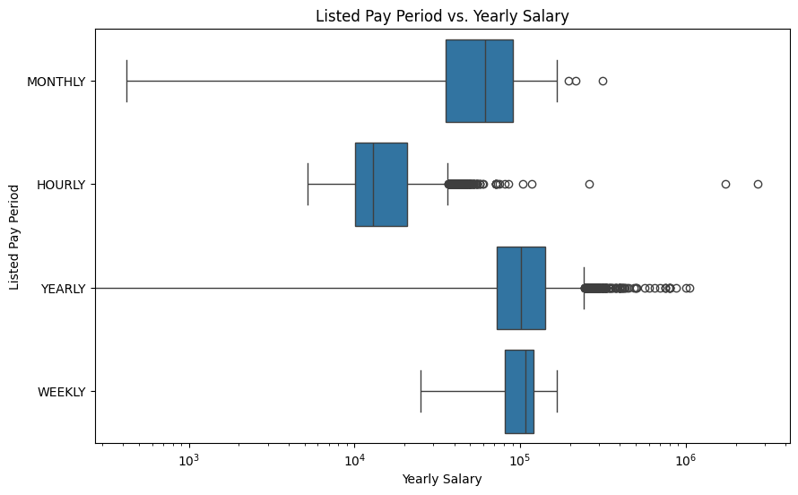

```python
# Plot side-by-side boxplots for pay_period vs salary
plt.figure(figsize=(10, 6))
sns.boxplot(x = "salary", y = "pay_period", data = job_postings, orient = 'h')

# Set logarithmic scale to see plot better
plt.xscale('log')

# Label plots
plt.xlabel("Yearly Salary")
plt.ylabel("Listed Pay Period")
plt.title("Listed Pay Period vs. Yearly Salary")

# Display
plt.show()
```

Interestingly enough, yearly salary seems to change depending on the pay period listed for the job. In particular, jobs that list hourly pay seem to have significantly lower salaries! This may in fact be a good indicator of what a job salary is like.

Just to be sure, let's run some data analysis to check for significant differences. As we cannot guarantee that our data has a normal distribution, we will run a Kruskal Wallis test on the medians.

1. **Null Hypothesis**: There is no significant difference between median yearly salary for different pay periods.
2. **Alternative Hypothesis**: There is a significant difference between median yearly salary for different pay periods.

Assume the null hypothesis.

```python
# Run a Kruskal Wallis Test on our different pay periods
hourly = job_postings[job_postings["pay_period"] == "HOURLY"]["salary"]
weekly = job_postings[job_postings["pay_period"] == "WEEKLY"]["salary"]
monthly = job_postings[job_postings["pay_period"] == "MONTHLY"]["salary"]
yearly = job_postings[job_postings["pay_period"] == "YEARLY"]["salary"]

stats, p_value = sci.stats.kruskal(hourly, weekly, monthly, yearly)

print("P-Value: ", p_value)
```

```
P-Value:  0.0
```

As our p-value is extremely close to 0, it is lower than our significance level of 0.05, making us reject our null hypothesis in favor of the alternative! Thus, we can say with reasonable confidence that there is a significant difference between median yearly salary for different pay periods. This tells us that pay periods may be a useful feature for predicting our yearly salary!

We explore many of our other features, to see if there are patterns within the yearly salaries that we could train our model on! We plot many of these features below.

First, let's take look at experience level.

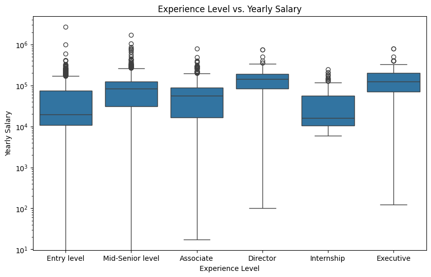

```python
# Plot side-by-side boxplots for exp_level vs salary
plt.figure(figsize=(10, 6))
sns.boxplot(x = "exp_level", y = "salary", data = job_postings)

# Set logarithmic scale to see plot better
plt.yscale('log')

# Label plots
plt.xlabel("Experience Level")
plt.ylabel("Yearly Salary")
plt.title("Experience Level vs. Yearly Salary")

# Display
plt.show()
```

Based on our boxplots, positions of different experience levels do seem to have different yearly salaries! Thus, experience level may also be a good predictor of yearly salary.

Now, let's take a look at job posting duration.

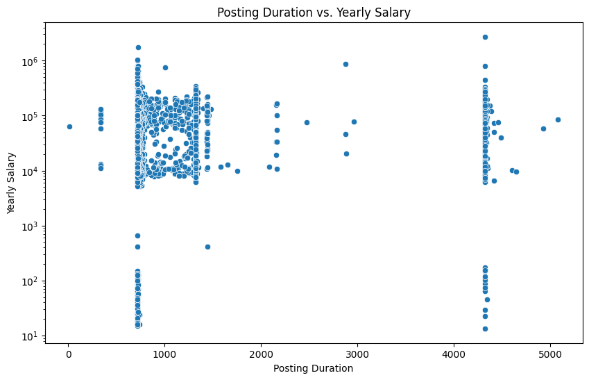

```python
# Plot side-by-side boxplots for time vs salary
plt.figure(figsize=(10, 6))
sns.scatterplot(x = "time", y = "salary", data = job_postings)

# Set logarithmic scale to see plot better
plt.yscale('log')

# Label plots
plt.xlabel("Posting Duration")
plt.ylabel("Yearly Salary")
plt.title("Posting Duration vs. Yearly Salary")

# Display
plt.show()
```

Now, let's take a look at work type.

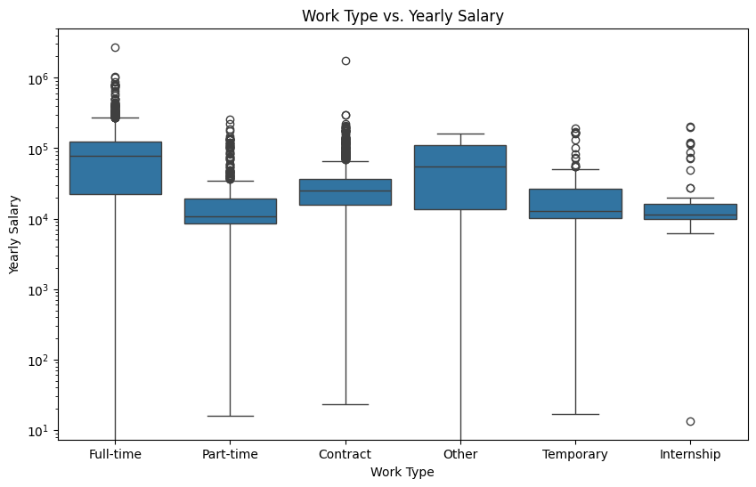

```python
# Plot side-by-side boxplots for work_type vs salary
plt.figure(figsize=(10, 6))
sns.boxplot(x = "work_type", y = "salary", data = job_postings)

# Set logarithmic scale to see plot better
plt.yscale('log')

# Label plots
plt.xlabel("Work Type")
plt.ylabel("Yearly Salary")
plt.title("Work Type vs. Yearly Salary")

# Display
plt.show()
```

Now, let's take a look at description length.

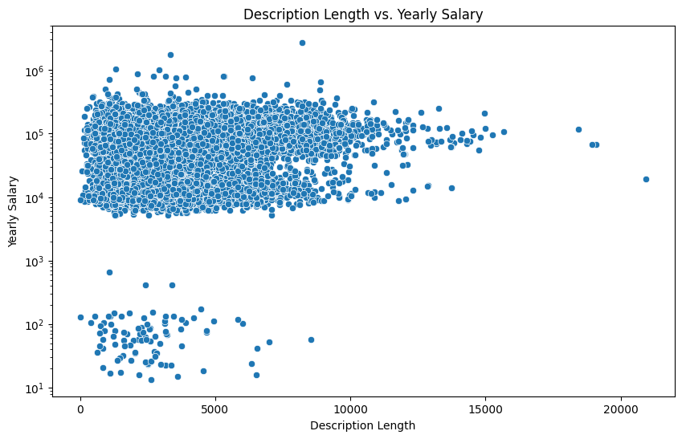

```python
# Plot side-by-side boxplots for desc_length vs salary
plt.figure(figsize=(10, 6))
sns.scatterplot(x = "desc_length", y = "salary", data = job_postings)

# Set logarithmic scale to see plot better
plt.yscale('log')

# Label plots
plt.xlabel("Description Length")
plt.ylabel("Yearly Salary")
plt.title("Description Length vs. Yearly Salary")

# Display
plt.show()
```

Now, let's take a look at differences between remote work being allowed and not allowed.

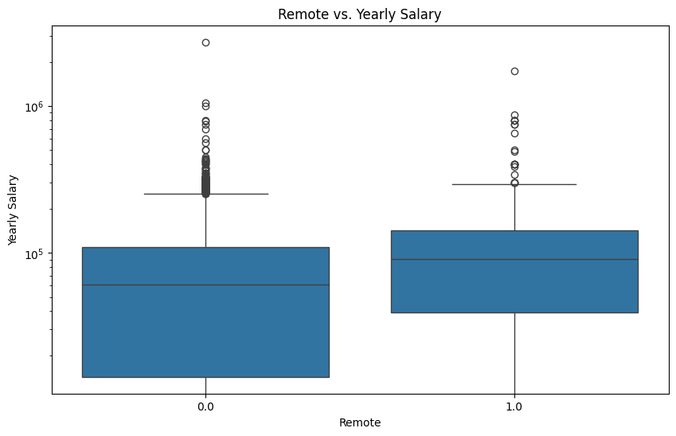

```python
# Plot side-by-side boxplots for remote_allowed vs salary
plt.figure(figsize=(10, 6))
sns.boxplot(x = "remote_allowed", y = "salary", data = job_postings)

# Set logarithmic scale to see plot better
plt.yscale('log')

# Label plots
plt.xlabel("Remote")
plt.ylabel("Yearly Salary")
plt.title("Remote vs. Yearly Salary")

# Display
plt.show()
```

Now, let's take a look at application type.

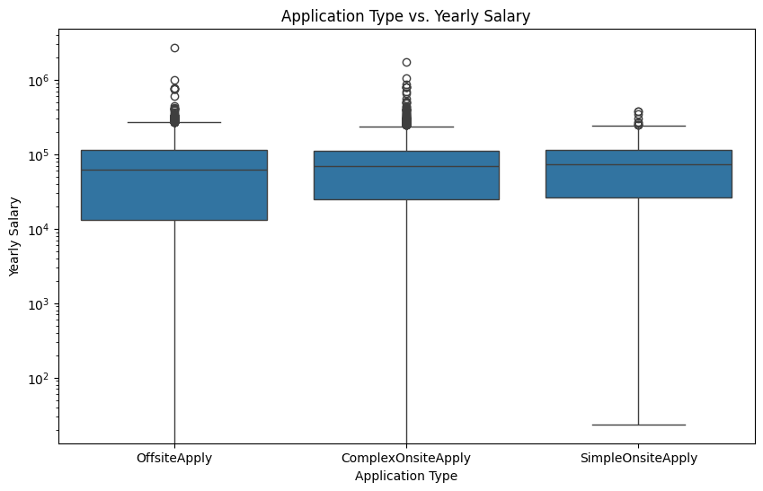

```python
# Plot side-by-side boxplots for application_type vs salary
plt.figure(figsize=(10, 6))
sns.boxplot(x = "application_type", y = "salary", data = job_postings)

# Set logarithmic scale to see plot better
plt.yscale('log')

# Label plots
plt.xlabel("Application Type")
plt.ylabel("Yearly Salary")
plt.title("Application Type vs. Yearly Salary")

# Display
plt.show()
```

Finally, let's take a look at our job benefits!

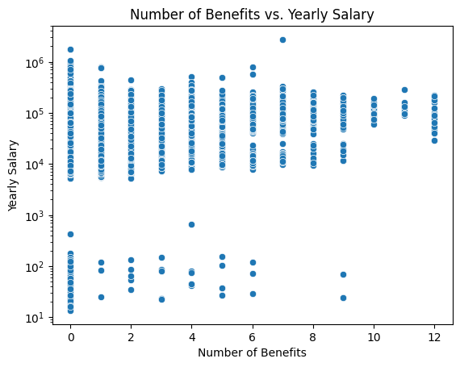

```python
# Sum the number of benefits listed for each job
def sum_benefits(row):
  sum = row["401(k)"] + row["Child care support"] + row['Commuter benefits'] + \
        row['Dental insurance'] + row['Disability insurance'] + row['Medical insurance'] + \
        row['Paid maternity leave'] + row['Paid paternity leave'] + row['Pension plan'] + \
        row['Student loan assistance'] + row['Tuition assistance'] + row['Vision insurance']
  return sum

sum_benefits = job_postings.apply(sum_benefits, axis = 1)

sns.scatterplot(x = sum_benefits, y = job_postings["salary"], data = job_postings)

plt.yscale('log')

plt.xlabel("Number of Benefits")
plt.ylabel("Yearly Salary")
plt.title("Number of Benefits vs. Yearly Salary")

plt.show()
```

In many of our features, we can see differences in our yearly salary between groups! This may give our model more patterns and thus more information to make a yearly salary prediction, giving us more insights into our question.

In the next section, we use these features in a machine learning model to see how accurately we can predict yearly salary, and what features are most important in these predictions.

# Primary Analysis

Based on the results from the exploratory data analysis, we decide to use a decision tree algorithm for our machine learning. To begin, our initial dataset already contains known values for our dependent variable: the average salary of the position; thus, we consider these values as “labels”, making our machine learning supervised. Not to mention, we would like to be able to use our final trained model on future LinkedIn job postings that may not provide their median salary but may provide the other attributes, and instead, predict their salaries ourselves. This way we can be better and more accurately prepared for their job interviews and salary expectation inquiries.

Our data contains multiple categorical values such as *work_type* and *pay_period* which make it difficult for linear regression to be applied. A decision tree would allow our model to learn from the categorical variables, generate appropriate probabilistic splits along the tree, and arrive at a confident prediction. Using the random forest algorithm also helps prevent overfitting and generates a more accurate model, for an otherwise complex decision tree.

A unique problem we encounter is the nature of our output. While many of our features are categorical, our output is numerical. A decision tree typically arrives at categorical classification: rainy or sunny, human or alien, True or False. However, because our ultimate goal is to predict a single numerical value along a continuous range, we have to use a **decision tree regressor**.

Briefly put, a **decision tree regressor** is similar to a typical decision tree with the added capability of producing a continuous output. The code we used came from the [sklearn.tree](https://scikit-learn.org/stable/modules/generated/sklearn.tree.DecisionTreeRegressor.html) package. Indeed, we could utilize typical decision trees and make the salary output categorical, such as “Less than \$25,000”, Between \$25,000 and \$50,000”, “Between \$50,000 and \$75,000” and “Greater than \$75,000” but in doing so, the results become uninformative. In other words, the results would be no better than the broad, vague salary ranges which can be easily found on Google. In effect, the decision tree regressor was the most suitable given our given dataset features and desired output.

We will also apply the [Random Forest](https://scikit-learn.org/stable/modules/generated/sklearn.ensemble.RandomForestRegressor.html) ensemble method, which creates multiple decision tree regressors (trained on different sections of the data) who "vote" on an outcome. This way, we avoid biases and overfitting, leaving us with a model that can reliably answer our question! For more information regarding Random Forest Regression, an interested reader can refer to the following resources:

- [Random Forest Regression Explained (GeeksForGeeks)](https://www.geeksforgeeks.org/random-forest-regression-in-python/)
- [Random Forest Regression Explained (TowardsDataScience)](https://towardsdatascience.com/random-forest-regression-5f605132d19d)
- [Random Forest Regression Explained (BuiltIn)](https://builtin.com/data-science/random-forest-python)

We begin by applying one-hot encoding on our categorical variables so that they're suitable for our model.

```python
job_data = job_postings.copy()

# One-hot encode work_type
one_hot_encoded = pd.get_dummies(job_data['work_type'], prefix='work_type',dtype=int)
job_data = pd.concat([job_data, one_hot_encoded], axis=1)

# One-hot encode application_type
one_hot_encoded = pd.get_dummies(job_data['application_type'], prefix='application_type',dtype=int)
job_data = pd.concat([job_data, one_hot_encoded], axis=1)

# One-hot encode exp_level
one_hot_encoded = pd.get_dummies(job_data['exp_level'], prefix='exp_level',dtype=int)
job_data = pd.concat([job_data, one_hot_encoded], axis=1)

# One-hot pay_period
one_hot_encoded = pd.get_dummies(job_data['pay_period'], prefix='pay_period',dtype=int)
job_data = pd.concat([job_data, one_hot_encoded], axis=1)
```

We now try to create, train, and test our model. To do this, we will use the RandomForestRegressor() classifier from `sklearn`.

```python
# Dropping columns that we are not considering features
columns_to_drop = ['job_id', 'company_id', 'work_type', 'applies', 'application_type', 'pay_period' ,'exp_level', 'salary']
X = job_data.drop(columns=columns_to_drop)

# Split the data into training and testing sets
X_train, X_test, y_train, y_test = train_test_split(X, job_data["salary"], test_size=0.2, random_state=42)

# Initialize the Random Forest Regressor
model = RandomForestRegressor()

# Training the Random Forest Regressor
model.fit(X_train, y_train)

# Make predictions on the testing set
y_pred = model.predict(X_test)

# Checking the mean squared error for the model
mse = mean_squared_error(y_test, y_pred)
r2 = r2_score(y_test, y_pred)
print('Mean Squared Error:', mse)
print('R^2:', r2)
```

```
Mean Squared Error: 4571296285.239265
R^2: 0.3929014395325998
```

Our model gives us an extremely high mean squared error, and a low $R^2$ coefficient! These indicate that our model has poor predictive power; the difference between the expected and predicted is large and this model does not account for much of the variance/relationship. In fact, we can expect this, as our salary does not follow a linear trend, and from our exploratory analysis, we can see that it moreso follows an exponential trend.

> An interested reader can read more on [mean squared error](https://statisticsbyjim.com/regression/mean-squared-error-mse/) and the [$R^2$ coefficient](https://statisticsbyjim.com/regression/interpret-r-squared-regression/) here!

Thus, to make our model better at predictions, we will apply a logarithm on our salaries, so that they become approximately more linear. This will make it easier for our regression model to predict. Let's try training the model again.

```python
job_data["salary"] = (job_data["salary"] + 1).astype(np.float32)
y = np.log(job_data["salary"])

# Dropping columns that we are not considering features
columns_to_drop = ['job_id', 'company_id', 'work_type', 'applies', 'application_type', 'pay_period' ,'exp_level', 'salary']
X = job_data.drop(columns=columns_to_drop)

# Split the data into training and testing sets
X_train, X_test, y_train, y_test = train_test_split(X, y, test_size=0.2, random_state=42)

# Initialize the Random Forest Regressor
model = RandomForestRegressor()

# Training the Random Forest Regressor
model.fit(X_train, y_train)

# Make predictions on the testing set
y_pred = model.predict(X_test)

# Checking the mean squared error for the model
mse = mean_squared_error(y_test, y_pred)
r2 = r2_score(y_test, y_pred)
print('Mean Squared Error:', mse)
print('R^2:', r2)
```

```
Mean Squared Error: 0.43785332993343407
R^2: 0.6732152648474137
```

Compared to before, our error has significantly reduced, and our $R^2$ has increased! Now, our model is a good predictor of our salaries. Specifically, an $R^2$ value of $.6732$ indicates that a moderately strong relationship exists between the various job features and the average salary.

Now that we know this, let's use our model to answer our questions!

# Visualization

Let's now answer our questions using our model.

First question - can you predict salary?

Below, we plot our predictions vs. actual data for some of our features. Observe how our model preserves the general patterns!

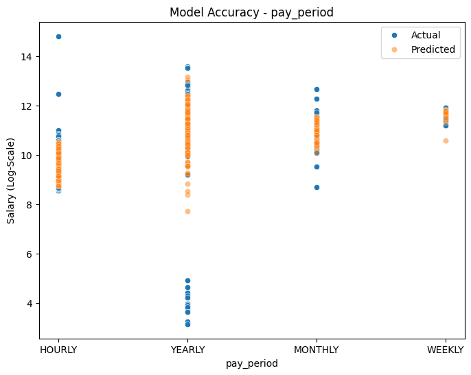

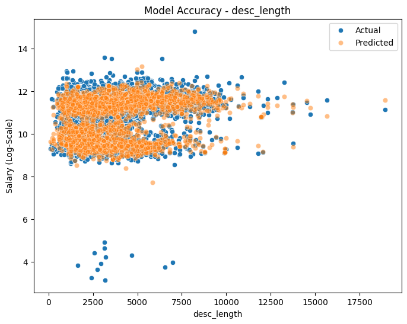

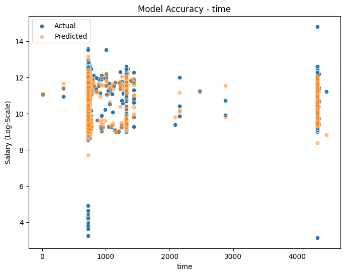

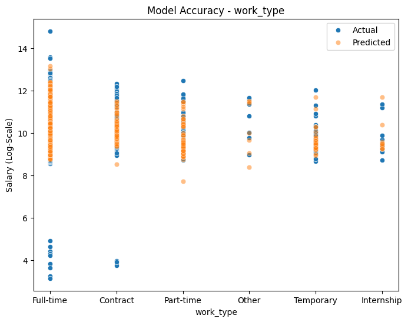

```python
# Split job_postings into corresponding training and testing set for visualization purposes
# We fix the seed to ensure this is the same split as before
X_jb = job_postings.drop(columns = "salary")
y_jb = np.log((job_postings["salary"] + 1).astype(np.float32))

jb_x_train, jb_x_test, jb_y_train, jb_y_test = train_test_split(X_jb, y_jb, test_size=0.2, random_state=42)

# Plot our predicted vs. actual data
for feature in ["pay_period", "desc_length", "time", "work_type"]:
    plt.figure(figsize=(8, 6))

    sns.scatterplot(x = jb_x_test[feature], y = y_test, label='Actual')
    sns.scatterplot(x = jb_x_test[feature], y = y_pred, label='Predicted', alpha=0.5)

    plt.xlabel(feature)
    plt.ylabel('Salary (Log-Scale)')
    plt.title(f'Model Accuracy - {feature}')
    plt.legend()
    plt.show()
```

Second question - if we can predict salary, which features are the most significant in this prediction?

Using our model, let's see what the model's most important features are.

```python
# Extract the feature importances from the model
feature = model.feature_importances_
feature_importance_df = pd.DataFrame({'Feature': X.columns, 'Importance': feature})
feature_importance_df = feature_importance_df.sort_values(by='Importance',ascending=False)
feature_importance_df.head(10)
```

|  | Feature | Importance |
| --- | --- | --- |
| 33 | pay_period_HOURLY | 0.536725 |
| 0 | desc_length | 0.097038 |
| 5 | follower_count | 0.085933 |
| 4 | employee_count | 0.074714 |
| 2 | views | 0.063894 |
| 3 | time | 0.021796 |
| 19 | work_type_Full-time | 0.018190 |
| 18 | work_type_Contract | 0.015821 |
| 32 | exp_level_Mid-Senior level | 0.007898 |
| 28 | exp_level_Director | 0.007283 |

Let's visualize this to make things easier to understand!

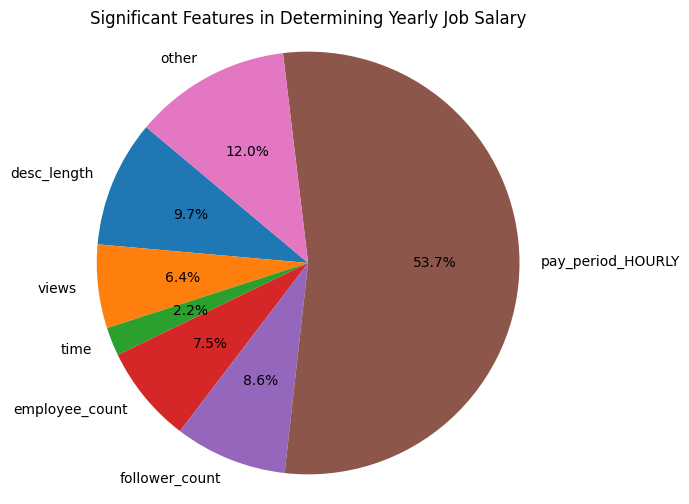

```python
# Group features below a certain threshold of importance
other_percent = 0

percentages = []
labels = []

for i in range(0, len(feature_importance_df)):
  label = feature_importance_df["Feature"][i]
  percent = feature_importance_df["Importance"][i]

  if percent < 0.02:
    other_percent += percent
  else:
    percentages.append(percent)
    labels.append(label)

percentages.append(other_percent)
labels.append("other")

# Plot pie chart
plt.figure(figsize=(6, 6))
plt.pie(percentages, labels = labels, autopct='%1.1f%%', startangle=140)
plt.axis('equal')
plt.title('Significant Features in Determining Yearly Job Salary')
plt.show()
```

Note that the `other` category consists of features contributing less than $2\%$ when predicting a job's average salary. They were condensed into a single category to increase readability on the chart.

From our pie chart, we see that our top 5 most important features are given in the following order:

1. Hourly Pay Period
2. Description Length
3. Follower Count
4. Employee Count
5. Application Views

This is the information an applicant should seek when applying to a job to accurately predict the yearly salary!

# Insights and Conclusions

## Analysis Summary

Through supervised machine learning, we were able to successfully develop a decision tree regressor model that can predict an average salary amount for a position given the position’s description length, pay period type, work type, remoteness, views, type of application, required experience level, job posting duration, company employee count, company follower count, and the company hiring benefits. Our most significant features were determined to be the type of pay period, the length of the job position description, and the amount of followers the company had among the other features.

Pay period was found to significantly contribute to the prediction of the yearly salary. This may be for a few reasons. For one, a yearly pay period often indicates a higher commitment to the position as opposed to an hourly pay period. Those who demonstrate a greater commitment may be rewarded with a greater salary. Additionally, a yearly pay period position’s salary is fixed while a hourly pay period salary is highly flexible. As a result, its salary is subject in the form of unfavorable situations like sickness or reduced workload/reduced need for workers, and the average salary decreases as a result.

Other possible explanations for our results is a longer job position description may mean the job’s responsibilities, qualifications, or prestige/status are higher. Greater responsibilities could lead to more work which typically results in greater pay, and since people with qualifications are desired more, a higher salay may incentivize them to apply for the position. Finally, a larger, wealthier company likely has more followers and thus has more capital. It is then able to pay its employees more than a poor company or company with little exposure and business.

Briefly put, our preprocessing involved deleting irrelevant features that logically would not help in determining salary such as number of applications or URL, imputing missing data in order to maintain a large training and testing data set, and condensing our dependent variable, the salary, to be just the average salary so it is standard across all data points.

The model we determined that was the most effective for answering our questions was the random forest regressor because we have a mix of categorical and numerical features but desired a numerical output. Moreover, the random forest ensemble method would help prevent overfitting. Overall, we produced a mean squared error of 0.4379 and an R^2 value of 0.6732. Evidently, our model is not perfect, but it does account for a majority of the the variance in our data and indicates a moderately strong relationship between our model and the dependent variable.

## Future Changes

Despite the insights we gained from this project, our results are certainly not perfect, and there's always room for improvement. One way we could improve our project is by using a higher quantity of data. Our dataset was taken over irregular time intervals from the LinkedIn job market, and while this did give us a fairly representative snapshot of the job market, the length of time for data collection was quite short, and there are numerous other online job boards applicants use. Thus, we can increase the quality of our model by combining data scraped from numerous other job boards, as well as simply collecting data over a longer period of time. Another way we could improve our project was by using more features. There is more to job applications than the features we used, and there may be extra characteristics in a job application which could be good predictors of salary, yet were not considered. If we could invest more time into training our model with more of these features, we may have a higher quality model.

Using our results so far, we can continue the results of our project to explore broader trends, such as time-based trends. The economy is rapidly changing - new industries are rising, old ones fading, and these influence job salaries. If we were able to repeat this project over regular intervals in a year, we could accumulate models trained on different periods of time, which could then be used to explore the state of the job market over time. This could also be generalized to the job markets of other countries, giving us a peek into changes in every country's ecnomy.

## Reflection

We believe both uninformed readers and informed readers would have something to gain from this project. We not only contextualize why our project is important, which may not be obvious to some readers, but also explore trends that are not often explored. While job applications may include salary ranges, these ranges are quite broad and uninformative, often leaving an applicant unsure whether or not the job is right for them. Our project not only provides a model that applicants can use to make finer salary predictions, but also describes general characteristics that applicants can look for (as a general rule of thumb) in their job search, which are often underlooked.

Throughout this project, we gained great insight into data science as a whole; data science, and specifically machine learning, allows researchers to identify previously invisible trends. It allows for the connection of ideas or variables, which seemingly have little logical relationship with each other, into a cohesive interpretation. Additionally, after some exploration into machine learning models, we learned that there do exist models that combine different machine learning concepts like regression and decision trees together. These prove especially useful in the real world where features are not as simple as one would expect; features are rarely all categorical or all numerical, so the continued development of models to account for different scenarios is extremely important. Finally, similar to the purpose of this exploration, there are various potential factors that account for a position’s salary. Some of these factors may actually be used by companies to establish salaries, and even the ones that are not exactly used, there is at least a correlation between the feature and the salary which one can use to more accurately predict a salary.